# Modul 01: Rancangan Percobaan Satu Faktor — RAL dan RAK

# 1 Pengantar Perancangan Percobaan Satu Faktor

Dalam penelitian pertanian, biologi, peternakan, dan perikanan, sebuah **percobaan ilmiah (*experiment*)** yang sah wajib memenuhi **tiga prinsip dasar Fisher**:

1. **Ulangan (*Replication*)**: Perlakuan diaplikasikan pada lebih dari satu satuan percobaan agar kita dapat menduga ragam **galat percobaan (*experimental error*)** dan memperkecil simpangan baku nilai tengah perlakuan ($\sigma_{\bar{Y}} = \sqrt{\sigma^2 / r}$).
2. **Pengacakan (*Randomization*)**: Penempatan perlakuan ke satuan percobaan dilakukan melalui mekanisme peluang agar galat percobaan saling bebas dan penduga perbedaan antar-perlakuan tidak berbias (*unbiased*).
3. **Pengendalian Lingkungan Lokal (*Local Control / Blocking*)**: Pengelompokan satuan-satuan percobaan yang seragam ke dalam satu blok apabila kondisi lingkungan tidak homogen, sehingga keragaman sistematis lingkungan dapat dipisahkan dari galat percobaan.

Modul ini membahas **Rancangan Percobaan Satu Faktor** secara menyeluruh mulai dari teknik pengacakan denah lapangan hingga pelaksanaan Analisis Ragam (*Analysis of Variance* / ANOVA) pada **Rancangan Acak Lengkap (RAL / CRD)** dan **Rancangan Acak Kelompok Lengkap (RAK / RCBD)**.

| Kriteria Pemilihan | Rancangan Acak Lengkap (RAL / CRD) | Rancangan Acak Kelompok (RAK / RCBD) |
| --- | --- | --- |
| **Kondisi Satuan Percobaan** | Sangat **homogen** (seragam di seluruh unit) | **Heterogen sistematis** pada satu arah gradasi |
| **Lokasi Khas** | Laboratorium, inkubator, kultur jaringan, rumah kaca terkontrol | Lahan sawah/kebun berlereng, kandang berbeda lokasi, bobot awal ternak beragam |
| **Prosedur Pengacakan** | Bebas penuh di seluruh $t \times r$ satuan percobaan | Dibatasi **terpisah di dalam masing-masing kelompok/blok** |
| **Derajat Bebas Galat ($\text{db}_g$)** | $t(r - 1)$ *(lebih besar pada jumlah petak sama)* | $(t - 1)(r - 1)$ *(berkurang sebesar $r - 1$ untuk blok)* |

# 2 Analisis 1.1: Pengacakan Layout RAL dan RAK

## 2.1 Penjelasan Awal (Konsep Dasar)

**Konsep Dasar — Mengapa Pengacakan Tidak Boleh Dilakukan “Suka-Suka”?**

Jika peneliti menempatkan perlakuan secara subjektif (misalnya semua petak pupuk `A` diletakkan di pinggir saluran irigasi dan pupuk `D` di bagian kering), maka pengaruh pupuk akan **terbaur (*confounded*)** dengan perbedaan kesuburan air.

- Pada **RAL (*Completely Randomized Design*)**, pengacakan dilakukan sekaligus terhadap seluruh $N = t \times r$ satuan percobaan tanpa batasan blok.
- Pada **RAK (*Randomized Complete Block Design*)**, lahan dibagi terlebih dahulu menjadi $r$ **kelompok (blok)** yang tegak lurus arah gradasi kesuburan, sehingga petak-petak **di dalam blok yang sama bersifat sehomogen mungkin**, sedangkan antar-blok dibuat semaksimal mungkin berbeda. Selanjutnya, ke-$t$ perlakuan diacak secara independen di dalam setiap blok.

## 2.2 Konteks Kasus & Kapan Menggunakan Analisis Ini

**Studi Kasus: Pengacakan Denah Lapangan:**

Seorang peneliti agronomi akan menguji **4 perlakuan pupuk** (`A`, `B`, `C`, dan `D`) masing-masing dengan **3 ulangan** (total $4 \times 3 = 12$ petak percobaan). * **Skenario 1 (RAL)**: Percobaan dilakukan dalam 12 pot tanah yang telah diayak dan dicampur homogen di rumah kaca. * **Skenario 2 (RAK)**: Percobaan dilakukan di lahan miring yang memiliki **3 tingkatan teras kesuburan** (Blok 1 = atas, Blok 2 = tengah, Blok 3 = bawah), sehingga setiap teras wajib memuat keempat perlakuan `A, B, C, D` tepat satu kali.

## 2.3 Model Peluang Pengacakan & Kombinatorika

Banyaknya kemungkinan tata letak pengacakan yang berpeluang sama untuk terpilih adalah:

$$\text{Banyak Denah RAL} = \frac{(t \cdot r)!}{(r!)^t}, \qquad \text{Banyak Denah RAK} = (t!)^r$$

Untuk $t = 4$ perlakuan dan $r = 3$ ulangan/kelompok:

- Pada **RAL**: terdapat $\frac{12!}{(3!)^4} = \frac{479.001.600}{1.296} = 369.600$ kemungkinan tata letak, di mana bisa saja secara kebetulan 2 atau 3 ulangan perlakuan `A` mengumpul di satu sisi.
- Pada **RAK**: terdapat $(4!)^3 = 24^3 = 13.824$ kemungkinan tata letak yang **menjamin** setiap perlakuan muncul tepat satu kali di setiap blok.

*Catatan: Pengacakan adalah tahap persiapan sebelum pengumpulan data, sehingga belum menguji hipotesis $H_0$, melainkan menjamin terpenuhinya asumsi kebebasan sisaan $\varepsilon_{ij} \overset{\text{iid}}{\sim} N(0, \sigma^2)$.*

## 2.4 Kode R Siap Pakai (Step-by-Step)

```r
# Memuat paket agricolae untuk perancangan percobaan pertanian
library(agricolae)

# Mendefinisikan vektor 4 taraf perlakuan pupuk
perlakuan <- c("A", "B", "C", "D")

# 1. Pengacakan RAL (4 perlakuan x 3 ulangan = 12 satuan percobaan)
#    Argumen seed = 512 menjamin hasil pengacakan dapat direproduksi persis sama
desain_ral <- design.crd(trt = perlakuan, r = 3, seed = 512, serie = 2)

# Menampilkan buku lapangan (fieldbook) urutan petak RAL
desain_ral$book
```

```
#>    plots r perlakuan
#> 1    101 1         C
#> 2    102 1         A
#> 3    103 1         D
#> 4    104 2         D
#> 5    105 2         A
#> 6    106 2         C
#> 7    107 3         D
#> 8    108 3         A
#> 9    109 1         B
#> 10   110 2         B
#> 11   111 3         C
#> 12   112 3         B
```

```r
# Menyusun tampilan visual denah 12 pot RAL dalam matriks 3 x 4
denah_ral <- matrix(
  paste0("Pot-", desain_ral$book$plots, " (", desain_ral$book$perlakuan, ")"),
  nrow = 3, ncol = 4, byrow = TRUE
)
print(denah_ral)
```

```
#>      [,1]          [,2]          [,3]          [,4]
#> [1,] "Pot-101 (C)" "Pot-102 (A)" "Pot-103 (D)" "Pot-104 (D)"
#> [2,] "Pot-105 (A)" "Pot-106 (C)" "Pot-107 (D)" "Pot-108 (A)"
#> [3,] "Pot-109 (B)" "Pot-110 (B)" "Pot-111 (C)" "Pot-112 (B)"
```

```r
# 2. Pengacakan RAK / RCBD (4 perlakuan x 3 kelompok = 12 petak sawah)
desain_rak <- design.rcbd(trt = perlakuan, r = 3, seed = 512, serie = 2)

# Menampilkan denah lapangan per blok (baris = blok, kolom = petak di dalam blok)
print(desain_rak$sketch)
```

```
#>      [,1] [,2] [,3] [,4]
#> [1,] "C"  "A"  "B"  "D"
#> [2,] "C"  "D"  "A"  "B"
#> [3,] "D"  "B"  "A"  "C"
```

```r
# Menampilkan buku lapangan RAK lengkap dengan nomor petak per blok (101..104, 201..204, 301..304)
desain_rak$book
```

```
#>    plots block perlakuan
#> 1    101     1         C
#> 2    102     1         A
#> 3    103     1         B
#> 4    104     1         D
#> 5    201     2         C
#> 6    202     2         D
#> 7    203     2         A
#> 8    204     2         B
#> 9    301     3         D
#> 10   302     3         B
#> 11   303     3         A
#> 12   304     3         C
```

## 2.5 Cara Membaca Output R & Kesimpulan Kasus

# 3 Analisis 1.2: ANOVA Satu Arah — Rancangan Acak Lengkap (RAL / CRD)

## 3.1 Penjelasan Awal (Konsep Dasar)

**Konsep Dasar — Bagaimana ANOVA Satu Arah Bekerja?**

Banyak pemula bertanya: *“Mengapa untuk membandingkan beberapa nilai rata-rata ($\mu_1, \mu_2, \dots, \mu_t$), metode yang dipakai justru bernama Analisis **Ragam** (ANOVA)?”*

Intuisinya sangat sederhana: ANOVA membandingkan **keragaman rata-rata antar-perlakuan (*Kuadrat Tengah Perlakuan* / KTP)** terhadap **keragaman alami individu di dalam perlakuan yang sama (*Kuadrat Tengah Galat* / KTG)**. * Jika rasio $F_{\text{hitung}} = \frac{\text{KTP}}{\text{KTG}} \approx 1$, berarti perbedaan antar-perlakuan hanyalah fluktuasi acak biasa. * Jika rasio $F_{\text{hitung}} \gg 1$ (jauh lebih besar dari 1), berarti perlakuan benar-benar menciptakan perbedaan respon yang nyata melampaui keragaman alami!

## 3.2 Konteks Kasus & Kapan Menggunakan Analisis Ini

**Studi Kasus RAL — Inokulasi Bakteri *Rhizobium* pada *Red Clover*:**

Gunakan **ANOVA Satu Arah (RAL)** apabila: 1. Hanya ada **satu faktor perlakuan** yang diteliti ($t \ge 2$ taraf). 2. Seluruh satuan percobaan (media tanam, cahaya, suhu, kelembaban) berada dalam kondisi **sangat homogen** sehingga tidak diperlukan pengelompokan (blok).

**Skenario Penelitian**: Suatu percobaan pot di rumah kaca dilakukan untuk menguji pengaruh inokulasi **6 kultur strain bakteri pengikat nitrogen *Rhizobium trifolii*** (yaitu `3DOK1`, `3DOK5`, `3DOK4`, `3DOK7`, `3DOK13`, dan campuran `Komposit`) terhadap **kadar nitrogen (mg)** tanaman *Red Clover* (*Trifolium pratense*), di mana setiap perlakuan diulang sebanyak **5 pot** (total $N = 6 \times 5 = 30$ satuan percobaan). Dataset tersimpan pada `data/02_red_clover_ral.csv`.

## 3.3 Model Linier, Rumus Dekomposisi JK, & Hipotesis

Model linier aditif untuk Rancangan Acak Lengkap dengan $t$ perlakuan dan $r$ ulangan adalah:

$$Y_{ij} = \mu + \tau_i + \varepsilon_{ij}; \quad i = 1, 2, \dots, t; \quad j = 1, 2, \dots, r$$

Keterangan simbol:

- $Y_{ij}$ : Nilai pengamatan kadar nitrogen pada perlakuan ke-$i$ ulangan ke-$j$.
- $\mu$ : Nilai tengah umum (*grand mean*) populasi.
- $\tau_i$ : Pengaruh aditif perlakuan strain *Rhizobium* ke-$i$ (dengan kendala $\sum_{i=1}^t \tau_i = 0$ untuk model pengaruh tetap).
- $\varepsilon_{ij}$ : Pengaruh acak galat percobaan pada perlakuan ke-$i$ ulangan ke-$j$, dengan asumsi $\varepsilon_{ij} \overset{\text{iid}}{\sim} N(0, \sigma^2)$.

Dekomposisi Jumlah Kuadrat (JK), Derajat Bebas (db), dan statistik uji $F$:

$$\text{JKT} = \text{JKP} + \text{JKG}, \qquad \text{db}_{\text{total}} = (tr - 1) = (t - 1) + t(r - 1)$$

$$F_{\text{hitung}} = \frac{\text{KTP}}{\text{KTG}} = \frac{\text{JKP} / (t - 1)}{\text{JKG} / [t(r - 1)]} \sim F_{(\alpha;\; t-1,\; t(r-1))}$$

$$\text{Koefisien Keragaman (KK)} = \frac{\sqrt{\text{KTG}}}{\bar{Y}_{\cdot\cdot}} \times 100\%$$

**Pasangan Hipotesis Statistik:**

- **$H_0 : \tau_1 = \tau_2 = \dots = \tau_6 = 0$** (Keenam strain bakteri *Rhizobium* memberikan rata-rata kadar nitrogen tanaman *Red Clover* yang sama).
- **$H_1 :$ Paling sedikit ada satu $\tau_i \neq 0$** untuk $i = 1, 2, \dots, 6$ (Minimal terdapat satu strain *Rhizobium* yang memberikan rata-rata kadar nitrogen berbeda nyata).

## 3.4 Kode R Siap Pakai (Step-by-Step)

```r
# Langkah 1: Membaca data dan menetapkan urutan faktor Perlakuan
df_clover <- read.csv("../data/02_red_clover_ral.csv")
df_clover$Perlakuan <- factor(
  df_clover$Perlakuan,
  levels = c("3DOK1", "3DOK5", "3DOK4", "3DOK7", "3DOK13", "Komposit")
)

# Langkah 2: Eksplorasi rata-rata, simpangan baku, dan jumlah ulangan tiap strain
ringkasan_clover <- do.call(
  data.frame,
  aggregate(Kadar_N ~ Perlakuan, data = df_clover,
            FUN = function(x) c(n = length(x), Mean = round(mean(x), 2), SD = round(sd(x), 2)))
)
print(ringkasan_clover)
```

```
#>   Perlakuan Kadar_N.n Kadar_N.Mean Kadar_N.SD
#> 1     3DOK1         5         28.8       2.30
#> 2     3DOK5         5         24.0       2.17
#> 3     3DOK4         5         14.6       2.07
#> 4     3DOK7         5         19.9       2.08
#> 5    3DOK13         5         13.2       1.93
#> 6  Komposit         5         18.7       2.00
```

```r
# Langkah 3: Menjalankan ANOVA Satu Arah (RAL) dengan fungsi aov()
model_ral <- aov(Kadar_N ~ Perlakuan, data = df_clover)
summary(model_ral)
```

```
#>             Df Sum Sq Mean Sq F value   Pr(>F)
#> Perlakuan    5  852.2  170.43   38.81 9.77e-11 ***
#> Residuals   24  105.4    4.39
#> ---
#> Signif. codes:  0 '***' 0.001 '**' 0.01 '*' 0.05 '.' 0.1 ' ' 1
```

```r
# Langkah 4: Menghitung KTG, Rata-rata Umum, Koefisien Keragaman (KK %), dan F-tabel
ktg_ral  <- summary(model_ral)[[1]]["Residuals", "Mean Sq"]
rata_ral <- mean(df_clover$Kadar_N)
kk_ral   <- sqrt(ktg_ral) / rata_ral * 100

cat(sprintf("Rata-rata Umum = %.2f mg | KTG = %.2f | KK = %.2f%%\n",
            rata_ral, ktg_ral, kk_ral))
```

```
#> Rata-rata Umum = 19.87 mg | KTG = 4.39 | KK = 10.55%
```

```r
cat(sprintf("Nilai kritis F_tabel(0.05; 5, 24) = %.2f | F_tabel(0.01; 5, 24) = %.2f\n",
            qf(0.95, 5, 24), qf(0.99, 5, 24)))
```

```
#> Nilai kritis F_tabel(0.05; 5, 24) = 2.62 | F_tabel(0.01; 5, 24) = 3.90
```

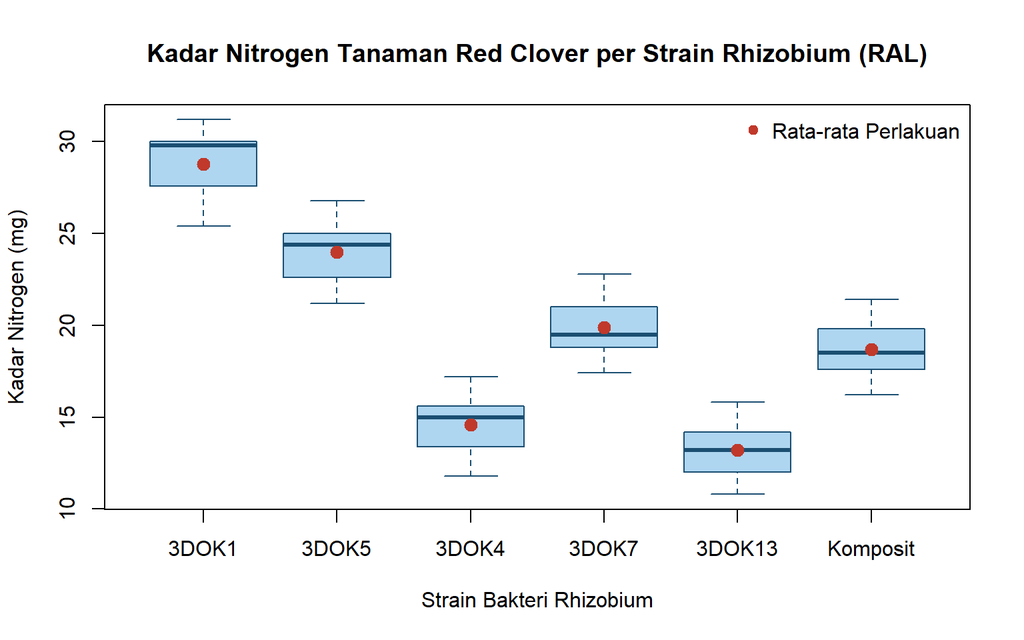

Figure 3.1: Sebaran dan titik rata-rata kadar nitrogen tanaman Red Clover pada 6 strain bakteri Rhizobium (RAL).

```r
# Langkah 5: Visualisasi Boxplot disertai titik rata-rata perlakuan (merah)
boxplot(Kadar_N ~ Perlakuan, data = df_clover,
        col  = "#aed6f1", border = "#1b4f72",
        main = "Kadar Nitrogen Tanaman Red Clover per Strain Rhizobium (RAL)",
        xlab = "Strain Bakteri Rhizobium",
        ylab = "Kadar Nitrogen (mg)")
rata_strain <- tapply(df_clover$Kadar_N, df_clover$Perlakuan, mean)
points(1:length(rata_strain), rata_strain, pch = 19, col = "#c0392b", cex = 1.3)
legend("topright", legend = "Rata-rata Perlakuan", pch = 19, col = "#c0392b", bty = "n")
```

## 3.5 Cara Membaca Output R & Kesimpulan Kasus

**Panduan Membaca Output `summary(model_ral)`:**

1. **Derajat Bebas (`Df`)**: Baris `Perlakuan` memiliki `Df = 5` ($t - 1 = 6 - 1 = 5$) dan baris `Residuals` (Galat) memiliki `Df = 24` ($t(r - 1) = 6 \times 4 = 24$). Pastikan angka ini selalu cocok dengan rumus sebelum membaca kolom lainnya!
2. **Jumlah Kuadrat (`Sum Sq`) & Kuadrat Tengah (`Mean Sq`)**:
   - $\text{JKP} = 852,2$ dengan $\text{KTP} = 852,2 / 5 = 170,43$.
   - $\text{JKG} = 105,4$ dengan $\text{KTG} = 105,4 / 24 = 4,39$. *(Catatan: Data pengamatan per pot pada CSV ini memiliki nilai tengah keenam strain sebesar `28,8; 24,0; 14,6; 19,9; 13,2; 18,7` mg).*
3. **Statistik Uji (`F value`) & Peluang Nyata (`Pr(>F)`)**:
   - Diperoleh **`F value = 38.81`** (jauh melampaui $F_{0.01(5,24)} = 3.90$) dengan **`Pr(>F) = 9.77e-11`** ($9,77 \times 10^{-11} < 0,001$, ditandai tiga bintang `***`).
   - Karena `Pr(>F) < 0.05`, maka **Tolak $H_0$** pada taraf nyata $\alpha = 5\%$ (bahkan sangat nyata pada $\alpha = 1\%$).
4. **Koefisien Keragaman (`KK = 10.55%`)**: Keragaman nisbi galat percobaan sebesar $10,55\%$ tergolong kecil/baik untuk percobaan biologis rumah kaca, menandakan kondisi pot terkendali dengan rapi.

**Kalimat Kesimpulan Siap Kutip (Format Laporan Penelitian):** > *“Berdasarkan hasil analisis ragam Rancangan Acak Lengkap, pemberian berbagai strain bakteri Rhizobium berpengaruh sangat nyata terhadap kadar nitrogen tanaman Red Clover ($F_{\text{hitung}} = 38,81 > F_{0,01(5, 24)} = 3,90$; $p\text{-value} = 9,77 \times 10^{-11} < 0,01$) dengan Koefisien Keragaman sebesar $10,55\%$. Rata-rata kadar nitrogen tertinggi dicapai pada inokulasi strain `3DOK1` ($28,80\text{ mg}$) dan terendah pada strain `3DOK13` ($13,20\text{ mg}$). Untuk menentukan pasangan strain mana saja yang berbeda nyata, analisis dilanjutkan dengan uji perbandingan berganda pada Modul 02.”*

# 4 Analisis 1.3: ANOVA Dua Arah Tanpa Interaksi — Rancangan Acak Kelompok (RAK / RCBD)

## 4.1 Penjelasan Awal (Konsep Dasar)

**Konsep Dasar — Bagaimana Pengelompokan (Blok) Mempertajam Uji $F$?**

Di lahan pertanian terbuka, hampir mustahil mendapatkan 24 petak sawah yang kesuburannya identik. Apabila kita memaksakan memakai RAL di lahan yang memiliki gradasi kesuburan, perbedaan kesuburan antar-petak akan masuk seluruhnya ke dalam **Jumlah Kuadrat Galat (JKG)**, membuat nilai **KTG membengkak** sehingga perbedaan nyata antar-pupuk gagal terdeteksi!

Pada **Rancangan Acak Kelompok (RAK / RCBD)**, keragaman total dipecah menjadi **tiga komponen**:
$$\text{Keragaman Total} = \text{Keragaman Perlakuan} + \text{Keragaman Kelompok (Blok)} + \text{Keragaman Galat}$$
Dengan “menyedot keluar” keragaman antar-kelompok ($\text{JKK}$) dari galat, nilai **KTG mengecil drastis** dan uji $F$ menjadi jauh lebih tajam/sensitif.

## 4.2 Konteks Kasus & Kapan Menggunakan Analisis Ini

**Studi Kasus RAK — Pemupukan NPK pada Padi Genotif S-969:**

Gunakan **ANOVA RAK** apabila: 1. Terdapat **satu faktor perlakuan** yang diuji, namun satuan percobaan memiliki **satu sumber keragaman lingkungan sistematis** (misalnya jarak petak sawah dari saluran irigasi primer, kemiringan lereng bukit, umur/bobot awal ternak, atau hari pengamatan berbeda). 2. Diasumsikan **tidak ada interaksi antara Kelompok dan Perlakuan** (selisih keunggulan pupuk relatif konsisten dari satu kelompok ke kelompok lain).

**Skenario Penelitian**: Suatu percobaan lapangan dilakukan untuk mengevaluasi pengaruh **6 kombinasi pupuk makro N, P, K** (`Kontrol`, `PK`, `N`, `NP`, `NK`, dan `NPK`) terhadap **hasil gabah kering (ton/ha) padi genotif S-969** yang ditanam pada **4 kelompok petak sawah** (`I`, `II`, `III`, `IV`) berdasarkan gradasi kesuburan lahan (total $6 \times 4 = 24$ petak). Dataset tersimpan pada `data/01_padi_rak_s969.csv`.

## 4.3 Model Linier, Rumus Efisiensi Relatif, & Hipotesis

Model linier aditif untuk Rancangan Acak Kelompok Lengkap tanpa interaksi adalah:

$$Y_{ij} = \mu + \tau_i + \beta_j + \varepsilon_{ij}; \quad i = 1, 2, \dots, t; \quad j = 1, 2, \dots, r$$

Keterangan simbol:

- $Y_{ij}$ : Hasil gabah padi (ton/ha) pada perlakuan pupuk ke-$i$ di kelompok sawah ke-$j$.
- $\mu$ : Nilai tengah umum populasi.
- $\tau_i$ : Pengaruh perlakuan pupuk ke-$i$ ($\sum_{i=1}^t \tau_i = 0$).
- $\beta_j$ : Pengaruh kelompok (blok) lahan ke-$j$ ($\sum_{j=1}^r \beta_j = 0$).
- $\varepsilon_{ij}$ : Pengaruh acak galat percobaan pada petak perlakuan ke-$i$ kelompok ke-$j$, dengan $\varepsilon_{ij} \overset{\text{iid}}{\sim} N(0, \sigma^2)$.

Dekomposisi Jumlah Kuadrat (JK) dan Statistik Uji $F$:

$$\text{JKT} = \text{JKK} + \text{JKP} + \text{JKG}, \qquad (tr - 1) = (r - 1) + (t - 1) + (t - 1)(r - 1)$$

$$F_{\text{hitung (Perlakuan)}} = \frac{\text{KTP}}{\text{KTG}} \sim F_{(\alpha;\; t-1,\; (t-1)(r-1))}, \qquad F_{\text{hitung (Kelompok)}} = \frac{\text{KTK}}{\text{KTG}} \sim F_{(\alpha;\; r-1,\; (t-1)(r-1))}$$

Untuk mengukur seberapa besar keuntungan pengelompokan dibandingkan jika seandainya dipakai RAL tanpa blok, kita dapat menghitung **Efisiensi Relatif (ER)**:

$$\widehat{\text{KTG}}_{\text{RAL}} = \frac{(r - 1)\text{KTK} + r(t - 1)\text{KTG}}{rt - 1}, \qquad \text{ER}(\%) = \frac{\widehat{\text{KTG}}_{\text{RAL}}}{\text{KTG}_{\text{RAK}}} \times 100\%$$

**Pasangan Hipotesis Statistik:**

1. **Hipotesis Utama (Pengaruh Perlakuan Pupuk)**:
   - $H_0 : \tau_1 = \tau_2 = \dots = \tau_6 = 0$ (Keenam kombinasi pupuk memberikan rata-rata hasil gabah padi S-969 yang sama).
   - $H_1 :$ Minimal ada satu $\tau_i \neq 0$ (Minimal ada satu kombinasi pupuk yang memberikan hasil gabah berbeda nyata).
2. **Hipotesis Pengelompokan (Efektivitas Blok)**:
   - $H_0 : \beta_1 = \beta_2 = \beta_3 = \beta_4 = 0$ (Tidak ada perbedaan hasil gabah antar-kelompok petak sawah).
   - $H_1 :$ Minimal ada satu $\beta_j \neq 0$ (Pengelompokan lahan efektif menangkap perbedaan kesuburan antar-blok).

## 4.4 Kode R Siap Pakai (Step-by-Step)

```r
# Langkah 1: Membaca data dan mengatur urutan level Perlakuan serta Kelompok
df_padi <- read.csv("../data/01_padi_rak_s969.csv")
df_padi$Perlakuan <- factor(
  df_padi$Perlakuan,
  levels = c("Kontrol", "PK", "N", "NP", "NK", "NPK")
)
df_padi$Kelompok <- factor(
  df_padi$Kelompok,
  levels = c("I", "II", "III", "IV")
)

# Langkah 2: Menampilkan tabel silang Perlakuan x Kelompok beserta nilai rata-ratanya
tabel_dua_arah <- xtabs(Hasil_Gabah ~ Perlakuan + Kelompok, data = df_padi)
round(addmargins(tabel_dua_arah, FUN = mean, quiet = TRUE), 2)
```

```
#>          Kelompok
#> Perlakuan    I   II  III   IV mean
#>   Kontrol 3.97 3.66 3.85 4.40 3.97
#>   PK      4.65 4.18 4.10 4.83 4.44
#>   N       5.60 5.02 5.15 5.63 5.35
#>   NP      5.82 5.40 5.55 6.03 5.70
#>   NK      5.90 5.38 5.60 6.12 5.75
#>   NPK     6.45 5.95 6.10 6.70 6.30
#>   mean    5.40 4.93 5.06 5.62 5.25
```

```r
# Langkah 3: Menjalankan ANOVA Dua Arah Tanpa Interaksi (RAK)
#            Gunakan tanda '+' (BUKAN '*') karena pada RAK standar diasumsikan tidak ada interaksi Blok x Perlakuan
model_rak <- aov(Hasil_Gabah ~ Kelompok + Perlakuan, data = df_padi)
summary(model_rak)
```

```
#>             Df Sum Sq Mean Sq F value   Pr(>F)
#> Kelompok     3  1.774  0.5915    98.8 4.19e-10 ***
#> Perlakuan    5 15.438  3.0876   515.7 3.18e-16 ***
#> Residuals   15  0.090  0.0060
#> ---
#> Signif. codes:  0 '***' 0.001 '**' 0.01 '*' 0.05 '.' 0.1 ' ' 1
```

```r
# Langkah 4: Menghitung KTG, KK (%), dan Efisiensi Relatif (ER) RAK terhadap RAL
tabel_anova_rak <- summary(model_rak)[[1]]
ktk_rak <- tabel_anova_rak["Kelompok", "Mean Sq"]
ktg_rak <- tabel_anova_rak["Residuals", "Mean Sq"]
kk_rak  <- sqrt(ktg_rak) / mean(df_padi$Hasil_Gabah) * 100

r_blok <- nlevels(df_padi$Kelompok)
t_perl <- nlevels(df_padi$Perlakuan)
ktg_duga_ral <- ((r_blok - 1) * ktk_rak + r_blok * (t_perl - 1) * ktg_rak) / (r_blok * t_perl - 1)
efisiensi_relatif <- (ktg_duga_ral / ktg_rak) * 100

cat(sprintf("KTG = %.4f | KK = %.2f%% | Efisiensi Relatif RAK vs RAL = %.1f%%\n",
            ktg_rak, kk_rak, efisiensi_relatif))
```

```
#> KTG = 0.0060 | KK = 1.47% | Efisiensi Relatif RAK vs RAL = 1375.6%
```

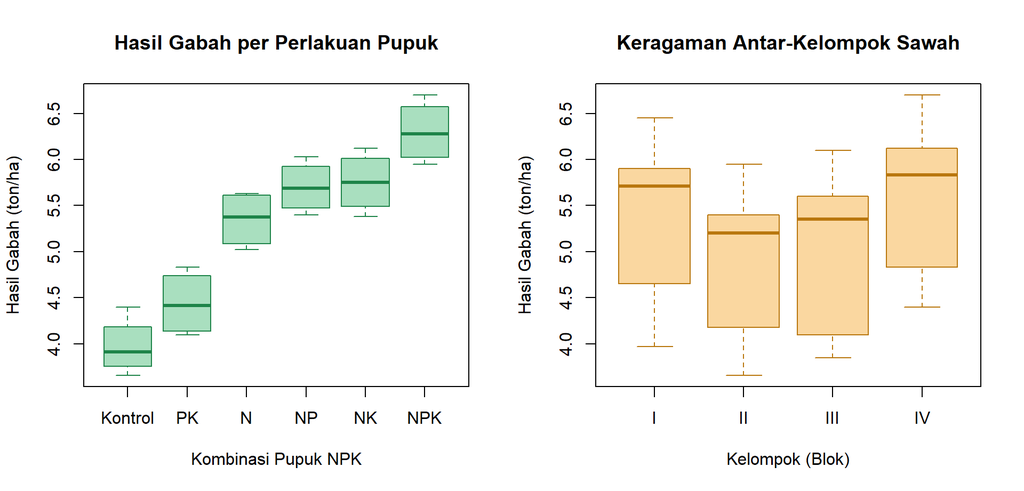

Figure 4.1: Perbandingan sebaran hasil gabah Padi S-969 berdasarkan perlakuan kombinasi pupuk (kiri) dan berdasarkan kelompok sawah (kanan).

```r
# Langkah 5: Visualisasi berdampingan efek Perlakuan dan efek Kelompok
par(mfrow = c(1, 2))
boxplot(Hasil_Gabah ~ Perlakuan, data = df_padi,
        col  = "#a9dfbf", border = "#1e8449",
        main = "Hasil Gabah per Perlakuan Pupuk",
        xlab = "Kombinasi Pupuk NPK", ylab = "Hasil Gabah (ton/ha)")

boxplot(Hasil_Gabah ~ Kelompok, data = df_padi,
        col  = "#fad7a0", border = "#b9770e",
        main = "Keragaman Antar-Kelompok Sawah",
        xlab = "Kelompok (Blok)", ylab = "Hasil Gabah (ton/ha)")
```

```r
par(mfrow = c(1, 1))
```

## 4.5 Cara Membaca Output R & Kesimpulan Kasus

**Panduan Membaca Output `summary(model_rak)`:**

1. **Periksa Derajat Bebas (`Df`)**:
   - `Kelompok` memiliki `Df = 3` ($r - 1 = 4 - 1 = 3$).
   - `Perlakuan` memiliki `Df = 5` ($t - 1 = 6 - 1 = 5$).
   - `Residuals` (Galat) memiliki `Df = 15` ($(t - 1)(r - 1) = 5 \times 3 = 15$). Jumlah total derajat bebas $= 3 + 5 + 15 = 23 = 24 - 1$ (cocok!).
2. **Evaluasi Pengaruh Perlakuan (`Perlakuan`)**:
   - Diperoleh **`F value = 515.7`** dengan **`Pr(>F) = 3.18e-16 ***`** ($< 0,001$).
   - Karena `Pr(>F) < 0.05`, maka **Tolak $H_0$ perlakuan**: kombinasi pupuk NPK berpengaruh sangat nyata terhadap hasil gabah padi S-969. Rata-rata hasil gabah meningkat tajam dari `Kontrol` ($3,97\text{ ton/ha}$) dan `PK` tanpa nitrogen ($4,44\text{ ton/ha}$) menuju pemupukan yang mengandung Nitrogen: `N` ($5,35\text{ ton/ha}$), `NP` ($5,70\text{ ton/ha}$), `NK` ($5,75\text{ ton/ha}$), hingga tertinggi pada `NPK` lengkap ($6,30\text{ ton/ha}$).
3. **Evaluasi Efektivitas Pengelompokan (`Kelompok`)**:
   - Diperoleh **`F value = 98.8`** dengan **`Pr(>F) = 4.19e-10 ***`** ($< 0,001$), di mana Kelompok IV memiliki rata-rata kesuburan tertinggi ($5,62\text{ ton/ha}$) sedangkan Kelompok II terendah ($4,93\text{ ton/ha}$).
   - Nilai **Efisiensi Relatif mencapai $1375,6\%$** dan **KK sangat kecil ($1,47\%$)**! Ini membuktikan bahwa keputusan peneliti menggunakan **RAK sangat tepat**: andaikata lahan ini dianalisis dengan RAL tanpa blok, KTG akan membengkak hampir 14 kali lipat!

**Kalimat Kesimpulan Siap Kutip (Format Laporan Penelitian):** > *“Hasil analisis ragam Rancangan Acak Kelompok menunjukkan bahwa pemberian kombinasi pupuk NPK berpengaruh sangat nyata terhadap hasil gabah padi genotif S-969 ($F_{\text{hitung}} = 515,70$; $p\text{-value} = 3,18 \times 10^{-16} < 0,01$). Pengelompokan petak sawah juga terbukti sangat efektif mengendalikan keragaman kesuburan lahan ($F_{\text{kelompok}} = 98,80$; $p\text{-value} = 4,19 \times 10^{-10} < 0,01$) sehingga menekan Koefisien Keragaman percobaan hingga $1,47\%$. Perlakuan pemupukan lengkap `NPK` menghasilkan rata-rata gabah tertinggi sebesar $6,30\text{ ton/ha}$, sedangkan petak `Kontrol` menghasilkan rata-rata terendah sebesar $3,97\text{ ton/ha}$.”*